# intro_to_ephys_nwbs-lazynwb

## Intro to Predictive Processing Ecephys NWBs

This notebook just shows how to extract the data-of-interest out of OpenScope's Predictive Process NWB files for Ecephys, which have been uploaded to the DANDI Archive.

The important information from experimental session in these files currently available are:

- Subject information
- Stimulus tables
- LFP (local field potential) traces
- Neuronal unit spike times from Kilosort4 and associated metrics
- Neuropixels probe electrodes table
- Eye tracking on screen (from deeplabcut)
- Running wheel rotation

```python
%matplotlib inline
import os
import pathlib
import tempfile
import time

import matplotlib.pyplot as plt
import numpy as np
import matplotlib as mpl
import polars as pl

# For benchmarking: use a new cache before importing lazynwb to ensure catalog scanning time is included
_lazynwb_demo_cache_dir = pathlib.Path(tempfile.mkdtemp(prefix="lazynwb-demo-cache-"))
os.environ["LAZYNWB_CATALOG_CACHE_PATH"] = str(_lazynwb_demo_cache_dir / "catalog.sqlite")
import lazynwb

# Set polars options for better notebook display
pl.Config.set_fmt_str_lengths(10_000).set_tbl_width_chars(-1)

# We're accessing a public dataset, so we can use anonymous access (credentials not required):
lazynwb.config.anon = True

t0 = time.perf_counter()
```

```python
%%time
dandiset_id = "001637"
dandi_filepath = "sub-820459/sub-820459_ses-ecephys-820459-2025-11-12-14-34-33_ecephys.nwb"

s3_source = lazynwb.get_dandi_sources(dandiset_id, version="draft", asset_filter=lambda asset: dandi_filepath in asset["path"])[0]
```

```
CPU times: total: 1.47 s
Wall time: 1.99 s
```

### Open NWB File

`lazynwb` has both a functional and an object-oriented API.

To get an overview of the structure of a single NWB file, we can load the analog of the `pynwb.NWBFile` object:

```python
%%time
nwb = lazynwb.LazyNWB(s3_source)
```

```
CPU times: total: 15.6 ms
Wall time: 6.58 ms
```

Creating the object for the file is lazy, but displaying the HTML representation triggers fetching metadata and the full tree of internal container paths:

```python
%%time
display(nwb)        # without display() the %%time reported is incorrect
```

NWB file: https://dandiarchive.s3.amazonaws.com/blobs/4b3/2a4/4b32a46d-f4de-467e-8cc8-ab354bef17cf

- **identifier:** 32129dc6-01a6-4f8b-9d62-a6aca6a54d4d

- **session_start_time:** 2025-11-12 14:34:33-08:00

- **session_id:** ecephys_820459_2025-11-12_14-34-33

- **session_description:** Base NWB file generated with subject metadata

- **experiment_description:** None

- **experimenter:** None

- **lab:** None

- **institution:** Allen Institute for Neural Dynamics

- **related_publications:** None

- **keywords:** []

- **notes:** None

- **data_collection:** None

- **surgery:** None

- **pharmacology:** None

- **virus:** None

- **source_script:** None

- **source_script_file_name:** None

Subject

- **age:** P108D

- **age__reference:** None

- **description:** None

- **genotype:** Sst-IRES-Cre/wt;Ai32(RCL-ChR2(H134R)_EYFP)/wt

- **sex:** F

- **species:** Mus musculus

- **subject_id:** 820459

- **weight:** None

- **strain:** None

- **date_of_birth:** 2025-07-27 00:00:00-07:53

Paths

**Click to expand**

- /acquisition/raw_running_wheel_rotation

- /acquisition/running_wheel_signal_voltage

- /acquisition/running_wheel_supply_voltage

- /intervals/40 hz pulse train_presentations

- /intervals/5 hz pulse train_presentations

- /intervals/Control block 1_presentations

- /intervals/Control block 2_presentations

- /intervals/Control block 3_presentations

- /intervals/Control block 4_presentations

- /intervals/RF mapping_presentations

- /intervals/Sequence mismatch block_presentations

- /intervals/Trippy_presentations

- /intervals/Zebra_presentations

- /intervals/raised_cosine_presentations

- /intervals/spontaneous_presentations

- /processing/ecephys/LFP/ElectricalSeriesProbeA-LFP

- /processing/ecephys/LFP/ElectricalSeriesProbeA-LFP/electrodes

- /processing/ecephys/LFP/ElectricalSeriesProbeB-LFP

- /processing/ecephys/LFP/ElectricalSeriesProbeB-LFP/electrodes

- /processing/ecephys/LFP/ElectricalSeriesProbeC-LFP

- /processing/ecephys/LFP/ElectricalSeriesProbeC-LFP/electrodes

- /processing/ecephys/LFP/ElectricalSeriesProbeD-LFP

- /processing/ecephys/LFP/ElectricalSeriesProbeD-LFP/electrodes

- /processing/ecephys/LFP/ElectricalSeriesProbeF-LFP

- /processing/ecephys/LFP/ElectricalSeriesProbeF-LFP/electrodes

- /processing/eye_tracking/corneal_reflection

- /processing/eye_tracking/ellipse

- /processing/eye_tracking/likely_blink_times

- /processing/eye_tracking/pupil

- /processing/running/running_speed

- /processing/running/running_wheel_rotation

- /processing/stimulus/timestamps

- /units

```
CPU times: total: 1.64 s
Wall time: 11.2 s
```

### Stimulus

Alternatively, one can access everything via the functional API, passing the s3 source and internal paths:

```python
INTERNAL_PATHS = lazynwb.get_internal_paths(s3_source, include_metadata=True)

for p in INTERNAL_PATHS:
    if p.startswith("/intervals/"):
        print(p)
```

```
/intervals/40 hz pulse train_presentations
/intervals/5 hz pulse train_presentations
/intervals/Control block 1_presentations
/intervals/Control block 2_presentations
/intervals/Control block 3_presentations
/intervals/Control block 4_presentations
/intervals/RF mapping_presentations
/intervals/Sequence mismatch block_presentations
/intervals/Trippy_presentations
/intervals/Zebra_presentations
/intervals/raised_cosine_presentations
/intervals/spontaneous_presentations
```

`get_df()` has fuzzy matching for internal paths, so you can pass the exact internal path or just a partial name but beware that there may be multiple matches!

```python
%%time
stim_table = nwb.get_df("Sequence mismatch block_presentations")
stim_table
```

```
CPU times: total: 656 ms
Wall time: 4.53 s
```

|  | BlockLabel | BlockNumber | BlockType | Delay | DiameterX | DiameterY | Duration | Orientation | SequenceNumber | SpatialFrequency | ... | phase | start_time | stim_block | stim_index | stim_name | stim_type | stop_time | _nwb_path | _table_path | _table_index |
| --- | --- | --- | --- | --- | --- | --- | --- | --- | --- | --- | --- | --- | --- | --- | --- | --- | --- | --- | --- | --- | --- |
| 0 | Sequence mismatch block | 2.0 | sequential_oddball | 0.0 | 360.0 | 360.0 | 0.25 | 1.5707963267948966 | 1.0 | 0.04 | ... | 0.0 | 435.529126 | 1.0 | 1.0 | Sequence mismatch block | None or Blank | 435.796017 | https://dandiarchive.s3.amazonaws.com/blobs/4b... | intervals/Sequence mismatch block_presentations | 0 |
| 1 | Sequence mismatch block | 2.0 | sequential_oddball | 0.0 | 360.0 | 360.0 | 0.25 | 0.7853981633974483 | 1.0 | 0.04 | ... | 0.0 | 435.796017 | 1.0 | 1.0 | Sequence mismatch block | None or Blank | 436.062908 | https://dandiarchive.s3.amazonaws.com/blobs/4b... | intervals/Sequence mismatch block_presentations | 1 |
| 2 | Sequence mismatch block | 2.0 | sequential_oddball | 0.0 | 360.0 | 360.0 | 0.25 | 0.0 | 1.0 | 0.04 | ... | 0.0 | 436.062908 | 1.0 | 1.0 | Sequence mismatch block | None or Blank | 436.329799 | https://dandiarchive.s3.amazonaws.com/blobs/4b... | intervals/Sequence mismatch block_presentations | 2 |
| 3 | Sequence mismatch block | 2.0 | sequential_oddball | 0.0 | 360.0 | 360.0 | 0.25 | 0.7853981633974483 | 1.0 | 0.04 | ... | 0.0 | 436.329799 | 1.0 | 1.0 | Sequence mismatch block | None or Blank | 436.596691 | https://dandiarchive.s3.amazonaws.com/blobs/4b... | intervals/Sequence mismatch block_presentations | 3 |
| 4 | Sequence mismatch block | 2.0 | sequential_oddball | 0.0 | 360.0 | 360.0 | 0.25 | 0.0 | 1.0 | 0.04 | ... | 0.0 | 436.596691 | 1.0 | 1.0 | Sequence mismatch block | None or Blank | 436.863584 | https://dandiarchive.s3.amazonaws.com/blobs/4b... | intervals/Sequence mismatch block_presentations | 4 |
| ... | ... | ... | ... | ... | ... | ... | ... | ... | ... | ... | ... | ... | ... | ... | ... | ... | ... | ... | ... | ... | ... |
| 6235 | Sequence mismatch block | 2.0 | sequential_oddball | 0.0 | 360.0 | 360.0 | 0.25 | 1.5707963267948966 | 1248.0 | 0.04 | ... | 0.0 | 2097.027287 | 1.0 | 1.0 | Sequence mismatch block | None or Blank | 2097.294176 | https://dandiarchive.s3.amazonaws.com/blobs/4b... | intervals/Sequence mismatch block_presentations | 6235 |
| 6236 | Sequence mismatch block | 2.0 | sequential_oddball | 0.0 | 360.0 | 360.0 | 0.25 | 0.7853981633974483 | 1248.0 | 0.04 | ... | 0.0 | 2097.294176 | 1.0 | 1.0 | Sequence mismatch block | None or Blank | 2097.561064 | https://dandiarchive.s3.amazonaws.com/blobs/4b... | intervals/Sequence mismatch block_presentations | 6236 |
| 6237 | Sequence mismatch block | 2.0 | sequential_oddball | 0.0 | 360.0 | 360.0 | 0.25 | 0.0 | 1248.0 | 0.04 | ... | 0.0 | 2097.561064 | 1.0 | 1.0 | Sequence mismatch block | None or Blank | 2097.827954 | https://dandiarchive.s3.amazonaws.com/blobs/4b... | intervals/Sequence mismatch block_presentations | 6237 |
| 6238 | Sequence mismatch block | 2.0 | sequential_oddball | 0.0 | 360.0 | 360.0 | 0.25 | 0.7853981633974483 | 1248.0 | 0.04 | ... | 0.0 | 2097.827954 | 1.0 | 1.0 | Sequence mismatch block | None or Blank | 2098.094849 | https://dandiarchive.s3.amazonaws.com/blobs/4b... | intervals/Sequence mismatch block_presentations | 6238 |
| 6239 | Sequence mismatch block | 2.0 | sequential_oddball | 0.0 | 360.0 | 360.0 | 0.25 | 0.0 | 1248.0 | 0.04 | ... | 0.0 | 2098.094849 | 1.0 | 1.0 | Sequence mismatch block | None or Blank | 2098.361745 | https://dandiarchive.s3.amazonaws.com/blobs/4b... | intervals/Sequence mismatch block_presentations | 6239 |

6240 rows × 28 columns

```python
np.unique(stim_table["TrialType"])
```

```
array(['halt', 'omission', 'orientation_45', 'orientation_90',
       'sequence_omission', 'standard'], dtype=object)
```

### LFP

```python
for p in INTERNAL_PATHS:
    if "LFP" in p:
        print(p)
```

```
/processing/ecephys/LFP/ElectricalSeriesProbeA-LFP
/processing/ecephys/LFP/ElectricalSeriesProbeA-LFP/electrodes
/processing/ecephys/LFP/ElectricalSeriesProbeB-LFP
/processing/ecephys/LFP/ElectricalSeriesProbeB-LFP/electrodes
/processing/ecephys/LFP/ElectricalSeriesProbeC-LFP
/processing/ecephys/LFP/ElectricalSeriesProbeC-LFP/electrodes
/processing/ecephys/LFP/ElectricalSeriesProbeD-LFP
/processing/ecephys/LFP/ElectricalSeriesProbeD-LFP/electrodes
/processing/ecephys/LFP/ElectricalSeriesProbeF-LFP
/processing/ecephys/LFP/ElectricalSeriesProbeF-LFP/electrodes
```

Conversion to `np.array` eagerly loads the data, which is a bad idea when streaming remote files - where possible, slice the data to read lazily instead:

```
(6767034,)
(6767034, 96)
```

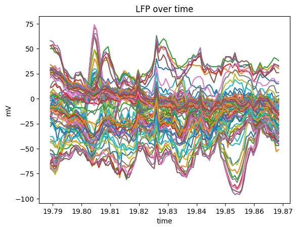

```
CPU times: total: 359 ms
Wall time: 862 ms
```

```python
%%time
lfp = nwb.get_timeseries("ProbeC-LFP")

print(lfp.timestamps.shape)
print(lfp.data.shape)


plt.plot(lfp.timestamps[:100], lfp.data[:100])
plt.xlabel("time")
plt.ylabel("mV")
plt.title("LFP over time")
plt.show()
```

### Spike Sorted Units and Metrics

The units table can be very large, with a mix of data scales: aside fraom scalar metrics columns, it contains list columns (spike times) and array columns (waveforms). When reading remote data, we want to extract only the rows and columns we need, and avoid materializing the entire table.

To do this, we use the concept of a `polars.LazyFrame`.

```python
%%time
units_lf = lazynwb.scan_nwb(s3_source, 'units')
display(units_lf)
```

NAIVE QUERY PLAN

run **LazyFrame.show_graph()** to see the optimized version

```
CPU times: total: 172 ms
Wall time: 244 ms
```

Nothing on a `LazyFrame` is computed until we call `collect()`, which triggers the computation and materializes a `DataFrame`. This allows us to do all of our slicing and dicing with lazy expressions, and only fetch the data we need when we call `collect()`.

```python
%%time
units_lf.collect_schema()
```

```
CPU times: total: 0 ns
Wall time: 0 ns
```

```
Schema([('amplitude', Float64),
        ('amplitude_cutoff', Float64),
        ('amplitude_cv_median', Float64),
        ('amplitude_cv_range', Float64),
        ('amplitude_median', Float64),
        ('d_prime', Float64),
        ('decoder_label', String),
        ('decoder_probability', Float64),
        ('default_qc', Boolean),
        ('depth', Float64),
        ('device_name', String),
        ('drift_mad', Float64),
        ('drift_ptp', Float64),
        ('drift_std', Float64),
        ('electrodes', List(Int64)),
        ('estimated_x', Float64),
        ('estimated_y', Float64),
        ('estimated_z', Float64),
        ('exp_decay', Float64),
        ('extremum_channel_index', Int64),
        ('firing_range', Float64),
        ('firing_rate', Float64),
        ('half_width', Float64),
        ('id', Int64),
        ('isi_violations_count', Int64),
        ('isi_violations_ratio', Float64),
        ('isolation_distance', Float64),
        ('ks_unit_id', Int64),
        ('l_ratio', Float64),
        ('nn_hit_rate', Float64),
        ('nn_miss_rate', Float64),
        ('num_negative_peaks', Int64),
        ('num_positive_peaks', Int64),
        ('num_spikes', Int64),
        ('original_cluster_id', Int64),
        ('peak_to_valley', Float64),
        ('peak_trough_ratio', Float64),
        ('presence_ratio', Float64),
        ('recovery_slope', Float64),
        ('repolarization_slope', Float64),
        ('rp_contamination', Float64),
        ('rp_violations', Int64),
        ('shank', String),
        ('silhouette', Float64),
        ('sliding_rp_violation', Float64),
        ('snr', Float64),
        ('spike_times', List(Float64)),
        ('spread', Int64),
        ('sync_spike_2', Float64),
        ('sync_spike_4', Float64),
        ('sync_spike_8', Float64),
        ('unit_name', String),
        ('velocity_above', Float64),
        ('velocity_below', Float64),
        ('waveform_mean', Array(Float64, shape=(210, 384))),
        ('waveform_sd', Array(Float64, shape=(210, 384))),
        ('_nwb_path', String),
        ('_table_path', String),
        ('_table_index', UInt32)])
```

To materialze a subset of columns, use `.select()`, then call `collect()`:

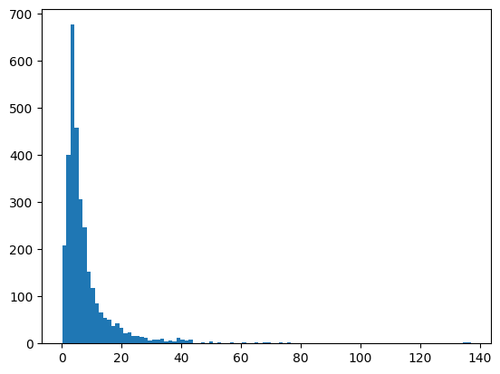

```python
plt.hist(units_lf.select("snr").collect()["snr"], bins=100)
plt.show()
```

To work with the units table: filter rows based on scalar metrics and metadata (unit quality, brain area), then select the data columns you need (e.g. spike times, waveforms):

```python
selected_units_lf = (
    units_lf
    .filter(
        "default_qc",                   # keep rows where this boolean col is True (indicates whether the unit passed default quality control criteria)
        pl.col("snr") > 10,        # AND only rows where the signal-to-noise ratio is greater than 10
                                        # filters can also be combined with & and |
    )
    .select("unit_name", "spike_times") # after applying the row filters above, only return these columns
)
selected_units_lf
```

NAIVE QUERY PLAN

run **LazyFrame.show_graph()** to see the optimized version

[figure not shown]

At first, this updated `LazyFrame` just contains the schema information and the query plan.

When we call `.collect()`, the query is executed and we get back a `DataFrame` with actual data:

```python
%%time
selected_units = selected_units_lf.collect()
selected_units
```

```
CPU times: total: 1.31 s
Wall time: 5.75 s
```

shape: (271, 2)

| unit_name str | spike_times list[f64] |
| --- | --- |
| "0c2661c9-07f9-47be-adcf-02515f0dcffc" | [19.810065, 19.833865, … 5431.404938] |
| "288071f9-7d26-487f-ab20-5b4d1462018d" | [19.857232, 20.041565, … 5433.369336] |
| "62934d5d-20d7-4709-a576-4e5c77b57d5c" | [19.818799, 20.265865, … 5433.359103] |
| "6adab19b-8918-4689-a729-a8f0fd5a0e7d" | [19.946799, 19.950799, … 5433.361803] |
| "911780b7-9faf-4520-956f-232a34abdc50" | [19.905399, 19.982832, … 5433.281536] |
| … | … |
| "d326c09a-bd51-487f-b3fe-e90e28689887" | [238.255196, 293.024038, … 5431.513474] |
| "c7dfd838-3891-47cc-84ef-c68bde55d883" | [29.935594, 32.531727, … 5431.236941] |
| "b1e38f45-f7ed-467d-9036-95669ef32768" | [25.245726, 25.258893, … 4990.138266] |
| "94bfadde-7ea4-455d-aca8-b53c9618b26c" | [93.214571, 118.520409, … 5432.618975] |
| "78cfb81a-1bcf-4a7f-bf8f-e4d23cf072f1" | [575.209353, 714.291976, … 5428.950274] |

To convert to a `pandas` dataframe, just call `.to_pandas()` on the `polars` dataframe. Note that list columns are handled as `object` dtype in pandas, so you may need to convert them to `numpy` arrays for easier handling.

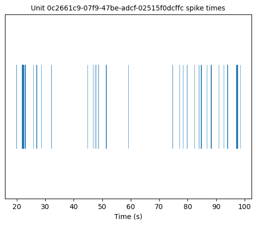

```python
# conversion to np.array required for plotting
unit0 = selected_units.to_dicts()[0]
plt.eventplot(unit0["spike_times"][:100], lw=0.5)
plt.title(f"Unit {unit0['unit_name']} spike times", fontsize=10)
plt.xlabel("Time (s)")
plt.yticks([])
plt.show()
```

### Electrodes and Unit Brain Location

```python
for p in INTERNAL_PATHS:
    if "general" in p:
        print(p)
```

```
/general/devices/ProbeA
/general/devices/ProbeB
/general/devices/ProbeC
/general/devices/ProbeD
/general/devices/ProbeF
/general/extracellular_ephys/ProbeA
/general/extracellular_ephys/ProbeB
/general/extracellular_ephys/ProbeC
/general/extracellular_ephys/ProbeD
/general/extracellular_ephys/ProbeF
/general/extracellular_ephys/electrodes
/general/subject
```

### Eye Tracking

```python
for p in INTERNAL_PATHS:
    if "eye_tracking" in p:
        print(p)
```

```
/processing/eye_tracking/corneal_reflection
/processing/eye_tracking/ellipse
/processing/eye_tracking/likely_blink_times
/processing/eye_tracking/pupil
```

```python
%%time
pupil_tracking = nwb.get_df('/processing/eye_tracking/pupil')
pupil_tracking
```

```
CPU times: total: 1.67 s
Wall time: 10.4 s
```

|  | angle | area | area_raw | data_x | data_y | height | id | reference_frame | timestamps | width | _nwb_path | _table_path | _table_index |
| --- | --- | --- | --- | --- | --- | --- | --- | --- | --- | --- | --- | --- | --- |
| 0 | -1.0 | 3.141593 | 3.141593 | -1.0 | -1.0 | -1.0 | 0 | nose | 14.39705 | -1.0 | https://dandiarchive.s3.amazonaws.com/blobs/4b... | processing/eye_tracking/pupil | 0 |
| 1 | -1.0 | 3.141593 | 3.141593 | -1.0 | -1.0 | -1.0 | 1 | nose | 14.41372 | -1.0 | https://dandiarchive.s3.amazonaws.com/blobs/4b... | processing/eye_tracking/pupil | 1 |
| 2 | -1.0 | 3.141593 | 3.141593 | -1.0 | -1.0 | -1.0 | 2 | nose | 14.43039 | -1.0 | https://dandiarchive.s3.amazonaws.com/blobs/4b... | processing/eye_tracking/pupil | 2 |
| 3 | -1.0 | 3.141593 | 3.141593 | -1.0 | -1.0 | -1.0 | 3 | nose | 14.44705 | -1.0 | https://dandiarchive.s3.amazonaws.com/blobs/4b... | processing/eye_tracking/pupil | 3 |
| 4 | -1.0 | 3.141593 | 3.141593 | -1.0 | -1.0 | -1.0 | 4 | nose | 14.46372 | -1.0 | https://dandiarchive.s3.amazonaws.com/blobs/4b... | processing/eye_tracking/pupil | 4 |
| ... | ... | ... | ... | ... | ... | ... | ... | ... | ... | ... | ... | ... | ... |
| 325152 | -1.0 | 3.141593 | 3.141593 | -1.0 | -1.0 | -1.0 | 325152 | nose | 5433.50180 | -1.0 | https://dandiarchive.s3.amazonaws.com/blobs/4b... | processing/eye_tracking/pupil | 325152 |
| 325153 | -1.0 | 3.141593 | 3.141593 | -1.0 | -1.0 | -1.0 | 325153 | nose | 5433.51848 | -1.0 | https://dandiarchive.s3.amazonaws.com/blobs/4b... | processing/eye_tracking/pupil | 325153 |
| 325154 | -1.0 | 3.141593 | 3.141593 | -1.0 | -1.0 | -1.0 | 325154 | nose | 5433.53513 | -1.0 | https://dandiarchive.s3.amazonaws.com/blobs/4b... | processing/eye_tracking/pupil | 325154 |
| 325155 | -1.0 | 3.141593 | 3.141593 | -1.0 | -1.0 | -1.0 | 325155 | nose | 5433.55179 | -1.0 | https://dandiarchive.s3.amazonaws.com/blobs/4b... | processing/eye_tracking/pupil | 325155 |
| 325156 | -1.0 | 3.141593 | 3.141593 | -1.0 | -1.0 | -1.0 | 325156 | nose | 5433.56847 | -1.0 | https://dandiarchive.s3.amazonaws.com/blobs/4b... | processing/eye_tracking/pupil | 325156 |

325157 rows × 13 columns

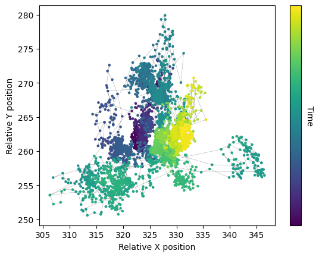

```python
xs = pupil_tracking['data_x']
ys = pupil_tracking['data_y']
start, end = 20, 5000

# generate colors along viridis for the range
colors = mpl.cm.viridis(np.linspace(0, 1, end-start))

# plot the line
plt.plot(xs[start:end], ys[start:end], zorder=0, linewidth=0.25, color='gray')

# scatter with colormap
sc = plt.scatter(xs[start:end], ys[start:end], s=5, c=colors, zorder=1)

plt.xlabel("Relative X position")
plt.ylabel("Relative Y position")

# colorbar for the gradient
cbar = plt.colorbar(sc)
cbar.ax.get_yaxis().labelpad = 15
cbar.ax.set_ylabel('Time', rotation=270)
cbar.set_ticks([])

plt.show()
```

### Running Wheel

```python
for p in INTERNAL_PATHS:
    if "running_wheel" in p:
        print(p)
```

```
/acquisition/raw_running_wheel_rotation
/acquisition/running_wheel_signal_voltage
/acquisition/running_wheel_supply_voltage
/processing/running/running_wheel_rotation
```

```python
%%time
wheel_rotation = nwb.get_df('/acquisition/raw_running_wheel_rotation')
wheel_times = wheel_rotation.timestamps
wheel_trace = wheel_rotation.data

print(wheel_times.shape)
print(wheel_trace.shape)
```

```
(265441,)
(265441,)
CPU times: total: 219 ms
Wall time: 983 ms
```

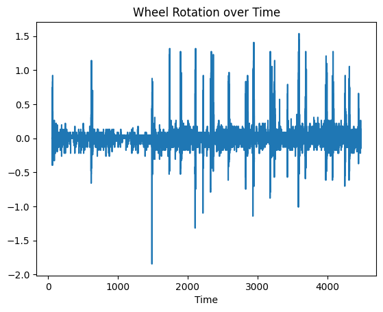

```python
plt.plot(wheel_times, wheel_trace)
plt.title("Wheel Rotation over Time")
plt.xlabel("Time")
plt.show()
```

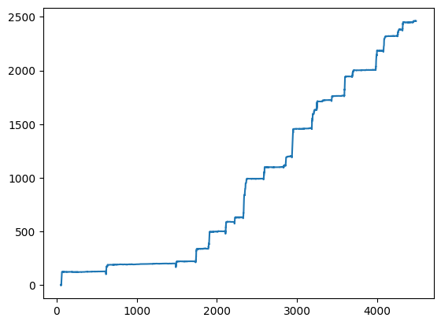

```python
plt.plot(wheel_times, np.cumsum(wheel_trace))
```

## Benchmark

Time elapsed (s):

```python
time.perf_counter() - t0
```

```
37.65523049997864
```

## Bonus: Multi-file access

One of the main features of `lazynwb` is the ability to access a concatenated table across any NWB files.

Let's fetch all the ecephys files in the same dandiset:

```python
%%time
s3_sources: list[str] = lazynwb.get_dandi_sources(dandiset_id, version="draft", asset_filter=lambda asset: "ecephys" in asset["path"])
print(len(s3_sources))
```

```
46
CPU times: total: 3min 54s
Wall time: 18.2 s
```

We can then construct a `LazyFrame` across all units in all files.

By default, `lazynwb` scans every file's units table schema individually and finds the common super-schema. If you know that every schema is the same, you can add the option `infer_schema_length=1` to just scan the first file.

```python
%%time
units_lf = lazynwb.scan_nwb(s3_sources, 'units')
```

```
CPU times: total: 4.89 s
Wall time: 4.34 s
```

The `_nwb_path` column is added to indicate the source file for each unit, and `_table_index` is a row's original index in its source file.

As with a single source, we use filter pushdown and column projection to limit the data read to only the bare minimum:

```python
%%time
(
    units_lf
    .select("default_qc", "_nwb_path", "_table_index")
    .group_by("_nwb_path")
    .agg(
        pl.col("_table_index").len().alias("n_units"),
        pl.col("default_qc").sum().truediv(pl.col("default_qc").count()).alias("proportion_good_units"),
    )
    .sort("n_units")
    .collect()
)
```

```
CPU times: total: 688 ms
Wall time: 411 ms
```

shape: (46, 3)

| _nwb_path str | n_units u32 | proportion_good_units f64 |
| --- | --- | --- |
| "https://dandiarchive.s3.amazonaws.com/blobs/4f9/03b/4f903bca-daeb-49dd-b0e9-39e26fa50395" | 2274 | 0.514952 |
| "https://dandiarchive.s3.amazonaws.com/blobs/6c7/720/6c7720ae-31b5-4f3a-bdd7-a9d67e6ddab1" | 2291 | 0.446966 |
| "https://dandiarchive.s3.amazonaws.com/blobs/8d7/8de/8d78de58-775b-484b-9647-3868d25cdd5a" | 2311 | 0.498486 |
| "https://dandiarchive.s3.amazonaws.com/blobs/471/e14/471e145f-1559-4f8e-b82f-51d413fe0137" | 2507 | 0.501795 |
| "https://dandiarchive.s3.amazonaws.com/blobs/836/a41/836a41c6-40a3-4f55-a714-7b9dd9994f38" | 2637 | 0.510049 |
| … | … | … |
| "https://dandiarchive.s3.amazonaws.com/blobs/a5b/695/a5b69541-98af-43e2-9583-b7acda6eaa99" | 4049 | 0.501111 |
| "https://dandiarchive.s3.amazonaws.com/blobs/c71/6b5/c716b5ff-a0c8-4d66-b5ed-f0f80004a4a3" | 4207 | 0.574043 |
| "https://dandiarchive.s3.amazonaws.com/blobs/883/47e/88347e17-850c-42c4-972a-fc24f1f2d60f" | 4210 | 0.575059 |
| "https://dandiarchive.s3.amazonaws.com/blobs/6e0/f10/6e0f1032-9c0f-41ff-8f0a-6830c667ae25" | 4247 | 0.596892 |
| "https://dandiarchive.s3.amazonaws.com/blobs/724/f2e/724f2e75-bc1e-460a-8081-997ab4aa2520" | 4363 | 0.53289 |